# Monte Carlo Simulation

Ayrin Sophie Piephoh

Department of Bioinformatics, University of Potsdam, Germany

Duygu Nur Arabaci

Department of Bioinformatics, University of Potsdam, Germany

Fatoumata Sow

Department of Bioinformatics, University of Potsdam, Germany

Mekontso Tepeu Florentin Jose

Department of Bioinformatics, University of Potsdam, Germany

Stevie Davies

Department of Bioinformatics, University of Potsdam, Germany

**Abstract**

This study employs Monte Carlo simulations to explore the dynamics of a beetle population in a virtual ecosystem, focusing on the impact of point size genetics on mating success and survival. Several different variations of an environment simulations were conducted with different initial agent numbers and probabilities favoring more points and less points.

# 1 Introduction

Monte Carlo simulation can be described as a mathematical tool that creates stochastic scenarios that are dependent on one or more unpredictable random variables (Paixão & Silva, 2019). Simulations and Monte Carlo simulations overall, are often used to solve problems that are deterministic in their nature (McDoniel & Monteleone, 2001). A Monte Carlo simulation is repeated various times, ranging from thousands to millions in the number of simulations runs.

The Monte Carlo Method was invented by John von Neumann and Stanislaw Ulam during World War II to improve decision making under uncertain conditions. It was named after a well-known casino town, called Monaco, since the element of chance is core to the modeling approach, similar to a game of roulette. Monte Carlo Simulations, used in various real-life scenarios like artificial intelligence and stock prices, offer dynamic analysis and adaptability, surpassing fixed-input predictive models.There exist lots of Monte Carlo simulations which have been carried out up to date. Some of which are :

- Monte Carlo simulation of an ecosystem : a matching between two levels of observation.This simulation presents a Monte Carlo computer simulation designed to depict the evolution of an ecosystem under specified environmental energy conditions. Preliminary results for a simple scenario reveal a compelling correlation between the detailed random behaviours of individual entities and a global deterministic model. This correlation has the potential to offer new insights into understanding and managing biomass production processes, serving as a valuable tool for evaluating classical treatments’ reliability.
- Monte Carlo simulation as a Marketing tool (Esa-Matti Korpioja, 2022): The simulations involve generating random variables using the inverse transform method, providing a simplified explanation of the process.

As hypothesis , we assume that an artificial society of lady beetles, governed by point size genetics, can exhibit complex social behaviors and survival strategies akin to natural ecosystems. By manipulating genetic preferences for point size, we aim to demonstrate how variations in genetic traits influence mating success, resource consumption, and population dynamics, offering insights into the evolutionary pressures and mating selection mechanisms in artificial populations.

# 2 Data and Methods

The `food` data frame represents the landscape’s food sources. It consists of randomly generated (x, y) coordinates, with a distribution that includes normal and uniform components. The `drawBeetle` function is defined to visually represent an individual beetle. The function utilizes ellipses to depict the body of the beetle and additional points for aesthetic details. The parameters such as position (x, y), sex, color, and the number of points influence the appearance of the beetle.

The `drawLandscape` function visualizes the landscape where the beetles reside. It includes a central circular region representing a high amount of food. Several trees are drawn across the landscape, indicated by polygons, to create diverse regions within the environment. The `drawBeetles` function integrates the individual beetle drawings into the landscape. It calls the `drawBeetle` function for each beetle in the `beetles` data frame, creating a comprehensive representation of the beetle population and their environment.

This simulation is implemented in R Statistical Software using the plotrix package. The environment undergoes iterations, where beetles move, interact, and consume energy. Mating preferences and energy consumption are determined by individual characteristics and the defined settings. The resulting visualizations provide insights into the distribution of beetles and food sources in the simulated landscape. In this simulation, agents take the form of beetles, with each beetle possessing distinct characteristics. These characteristics include the number of points on their bodies, influencing their attractiveness during mating, and their sight range, affecting their ability to locate food and potential mates.

The simulation considers two settings for the beetle agents’ point size genetics: one favoring fewer points and another favoring more points. The parameter “favored” specifies this preference, with options “more” or else. The number of points on a beetle plays a crucial role in determining its attractiveness during mating.

The sight range of each beetle is determined by specific formulas based on their point size genetics. For more points preference, the formula is sight = points[f] - 1. For fewer points preference, the formula is sight = 7 - points/2. Mating preferences in the simulation are influenced by the number of points on beetles. For females, the probability of choosing a male is directly related to the number of points. In contrast, the chance of mating for males is determined by the ratio of their points to the total possible points (7 points). Males with more points have a higher probability of being selected. The landscape in the simulation incorporates food sources that provide energy to the beetles. The energy loss for a beetle in each iteration is determined by the number of points on the beetle and the mating preference setting. The energy loss formula varies based on the preference setting: for more points preference, the energy loss is a constant 1 per iteration, while for fewer points preference, energy loss increases with the number of points.

- Initialization: A specified number of agents (beetles) are created in the environment during this step. The initial agent counts can be adjusted as a parameter setting.
- Iteration: The simulation progresses through multiple iterations, simulating the passage of time. During each iteration, agents (beetles) move, interact, and consume energy.
- Mating: Mating preferences, based on point size genetics, are implemented during this step. The simulation calculates the chances of successful mating for each beetle.
- Energy Consumption: The energy loss for each beetle in each iteration is determined based on their individual characteristics and mating preferences.

Simulation of the beetle environment was done using the plotrix package (3.8.4) in R, providing a graphical representation of the distribution of beetles and food sources in the environment. All analyses were performed using R Statistical Software (R version 4.3.0 (2023-04-21 ucrt); R Core Team 2023).

# 3 Results and Discussion

In this paper, a community of beetles were simulated using Monte Carlo methods, and the population of beetles were observed according to their point numbers. Several simulations with varying initial agent counts were run under probabilities that favored higher and lower point numbers. The results were plotted alongside average point count of the beetles.

```
## [1] "1 beetle(s) in lake, dying ..."
```

```
## [1] "12 mates prosperous 18"
## [1] "removing 0 food items ..."
## [1] "removing 4 food items ..."
## [1] "removing 5 food items ..."
## [1] "removing 7 food items ..."
## [1] "removing 7 food items ..."
## [1] "8 mates prosperous 16"
## [1] "removing 7 food items ..."
```

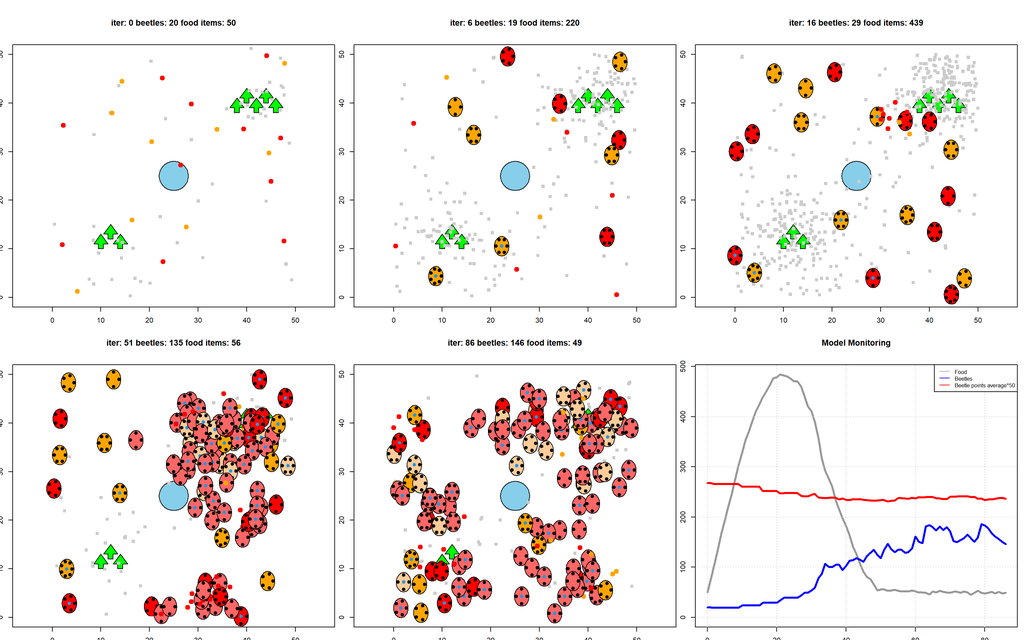

Figure 3.1: Beetle Simulations

```
## [1] "7 mates prosperous 4"
## [1] "removing 2 food items ..."
## [1] "removing 4 food items ..."
## [1] "removing 10 food items ..."
## [1] "5 mates prosperous 8"
## [1] "removing 17 food items ..."
## [1] "removing 10 food items ..."
## [1] "removing 9 food items ..."
## [1] "removing 17 food items ..."
## [1] "1 beetle(s) in lake, dying ..."
## [1] "removing 22 food items ..."
## [1] "removing 32 food items ..."
## [1] "removing 20 food items ..."
## [1] "removing 24 food items ..."
## [1] "removing 21 food items ..."
```

[output cut: 44 more lines]

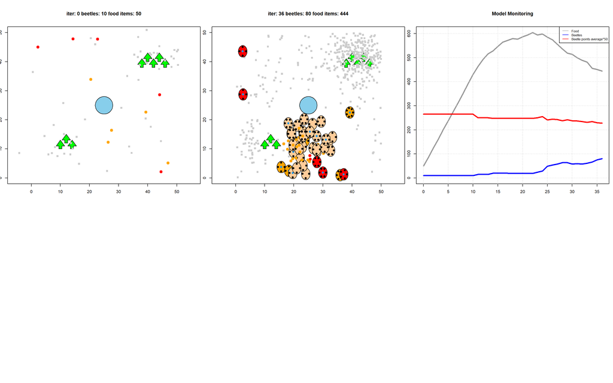

Figure 3.2: Beetle Simulations, starting agents: 10, favored: less

```
## [1] "1 beetle(s) in lake, dying ..."
## [1] "removing 1 food items ..."
## [1] "removing 4 food items ..."
## [1] "removing 7 food items ..."
## [1] "removing 7 food items ..."
## [1] "11 mates prosperous 8"
## [1] "removing 5 food items ..."
## [1] "removing 5 food items ..."
## [1] "removing 12 food items ..."
## [1] "removing 22 food items ..."
## [1] "removing 11 food items ..."
## [1] "removing 12 food items ..."
## [1] "removing 8 food items ..."
## [1] "removing 11 food items ..."
## [1] "removing 14 food items ..."
```

[output cut: 23 more lines]

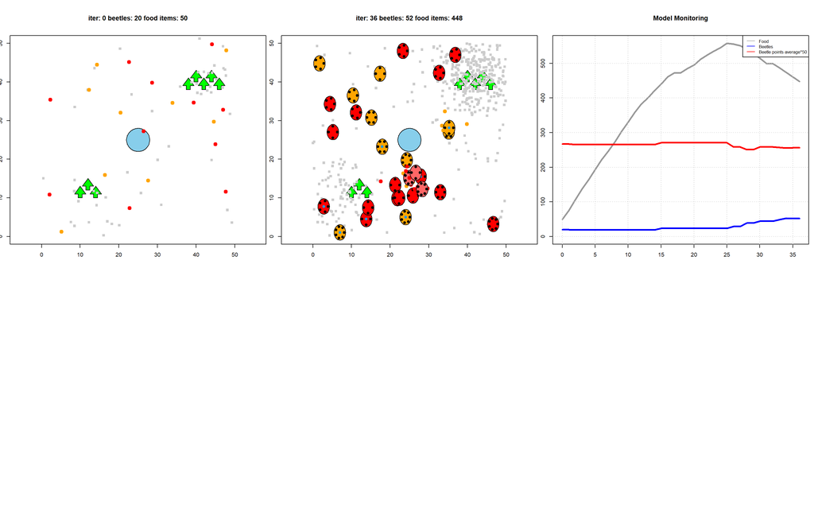

Figure 3.3: Beetle Simulations, starting agents: 20, favored: less

```
## [1] "1 beetle(s) in lake, dying ..."
## [1] "7 mates prosperous 12"
## [1] "removing 0 food items ..."
## [1] "3 mates prosperous 32"
## [1] "29 mates prosperous 31"
## [1] "removing 2 food items ..."
## [1] "removing 0 food items ..."
## [1] "3 mates prosperous 24"
## [1] "removing 4 food items ..."
## [1] "removing 1 food items ..."
## [1] "removing 3 food items ..."
## [1] "14 mates prosperous 28"
## [1] "removing 5 food items ..."
## [1] "removing 3 food items ..."
## [1] "17 mates prosperous 27"
```

[output cut: 51 more lines]

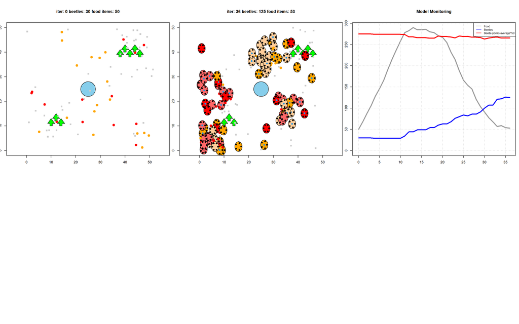

Figure 3.4: Beetle Simulations, starting agents: 30, favored: less

```
## [1] "removing 3 food items ..."
## [1] "removing 6 food items ..."
## [1] "removing 9 food items ..."
## [1] "removing 12 food items ..."
## [1] "removing 17 food items ..."
## [1] "removing 11 food items ..."
## [1] "removing 11 food items ..."
## [1] "removing 21 food items ..."
## [1] "removing 19 food items ..."
## [1] "removing 33 food items ..."
## [1] "removing 18 food items ..."
## [1] "5 mates prosperous 2"
## [1] "removing 21 food items ..."
## [1] "3 mates prosperous 15"
## [1] "removing 19 food items ..."
```

[output cut: 29 more lines]

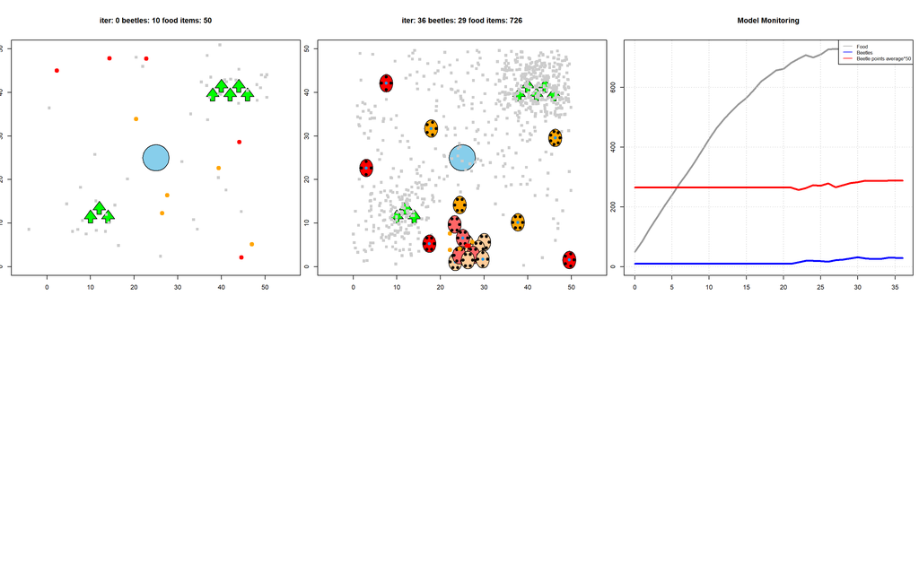

Figure 3.5: Beetle Simulations, starting agents: 10, favored: more

```
## [1] "1 beetle(s) in lake, dying ..."
## [1] "15 mates prosperous 5"
## [1] "9 mates prosperous 2"
## [1] "10 mates prosperous 13"
## [1] "18 mates prosperous 21"
## [1] "removing 0 food items ..."
## [1] "4 mates prosperous 17"
## [1] "10 mates prosperous 14"
## [1] "removing 2 food items ..."
## [1] "4 mates prosperous 28"
## [1] "removing 2 food items ..."
## [1] "33 mates prosperous 23"
## [1] "removing 3 food items ..."
## [1] "26 mates prosperous 20"
## [1] "3 starving and dying ..."
```

[output cut: 68 more lines]

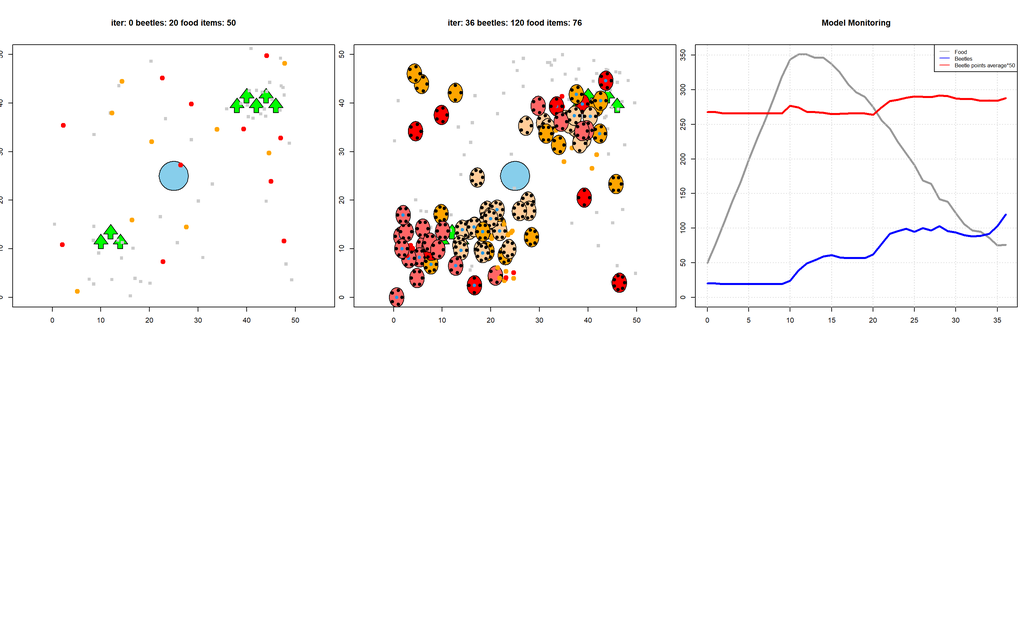

```
## [1] "6 mates prosperous 3"
## [1] "30 mates prosperous 11"
## [1] "26 mates prosperous 25"
## [1] "2 starving and dying ..."
## [1] "removing 0 food items ..."
## [1] "8 mates prosperous 12"
## [1] "34 mates prosperous 18"
## [1] "2 starving and dying ..."
## [1] "removing 2 food items ..."
## [1] "23 mates prosperous 22"
## [1] "removing 1 food items ..."
## [1] "4 mates prosperous 54"
## [1] "29 mates prosperous 16"
## [1] "removing 4 food items ..."
## [1] "12 mates prosperous 46"
```

[output cut: 74 more lines]

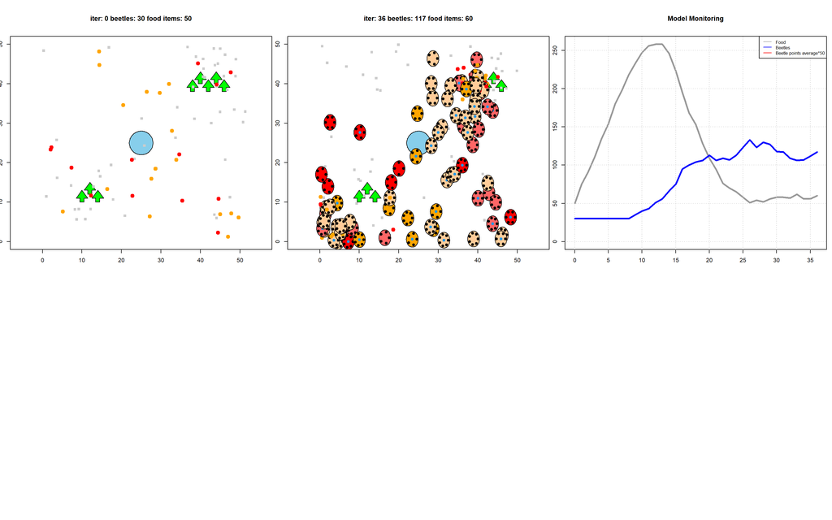

The simulations reveal fascinating insights into how food availability shapes the population of simulated beetles. Fluctuations in food directly influence the overall beetle population, leading to significant changes over time. Individual beetle characteristics, such as their assigned points, play a crucial role in determining mating success and overall survival.

The simulations illustrate a dynamic interplay among food availability, mating success, and changes in the beetle population. These factors are interconnected, contributing to the evolving dynamics of the simulated beetle ecosystem. The findings highlight the complexity of factors influencing population dynamics, including initial conditions, environmental factors, and individual beetle characteristics.

# 4 Discussion

## 4.1 Advantages and limitations of the Monte Carlo simulation

The Monte Carlo simulation is a versatile tool that possesses many advantages across diverse applications. The fact that this simulation is very flexible makes it adaptable to a broad spectrum of problem domains. One key aspect is the ability to assess and quantify risks and the technique excels in modelling complex systems, capturing inter-dependencies and relationships among variables that might challenge traditional analytic methods. It also possesses a sensitivity analysis component which allows its user to identify the most influential factors, guiding resource allocation. Its proficiency in exploring realistic scenarios while integrating statistical methods, and ability to handle non-linearity contributes to its status as a go-to method for decision analysis and risk management. However, this simulation also has some limitations. The simulation relies on one fundamental assumption which is the independence of random variables, which may lead to inaccuracies when correlations exist between variables.

Additionally, Monte Carlo simulations may not be well-suited for systems with deterministic inputs, and their effectiveness becomes lower in cases of discontinuities, non-linearities, or interdependent events. Caution is advised when it comes to interpretation challenges and the difficulty of handling rare events with low probabilities.

# Bibliography

Giro, A., J. A. Padro, J. Valls, and J. Wagensberg. 1985. “Monte Carlo Simulation of an Ecosystem: A Matching Between Two Levels of Observation.” *Bulletin of Mathematical Biology* 47 (1): 111–22. https://doi.org/10.1007/bf02459648.

J, Lemon. 2006. “Plotrix: A Package in the Red Light District of r.” *R-News* 6 (4): 8–12.

Lemon, Jim, Ben Bolker, Sander Oom, Eduardo Klein, Barry Rowlingson, Hadley Wickham, Anupam Tyagi, et al. 2023. *Plotrix: Various Plotting Functions*. https://github.com/dmurdoch/plotrix.

Paixão, Kevin William, and Adriano Maniçoba Silva. 2019. “Sales Forecasting in a Mechanical Component Manufacturer: Comparison Between Monte Carlo Simulation and Time Series Analysis.” *Independent Journal of Management &Amp; Production* 10 (4): 1324. https://doi.org/10.14807/ijmp.v10i4.998.

R Core Team. 2023. *R: A Language and Environment for Statistical Computing*. Vienna, Austria: R Foundation for Statistical Computing. https://www.R-project.org/.

Raymond, Daniel. 2023. “Top 10 Cons & Disadvantages of Monte Carlo Analysis.” *Articles for Project Managers - The Project Management Network*. https://projectmanagers.net/top-10-cons-disadvantages-of-monte-carlo-analysis/.

Xie, Yihui. 2014. “Knitr: A Comprehensive Tool for Reproducible Research in R.” In *Implementing Reproducible Computational Research*, edited by Victoria Stodden, Friedrich Leisch, and Roger D. Peng. Chapman; Hall/CRC.

———. 2015. *Dynamic Documents with R and Knitr*. 2nd ed. Boca Raton, Florida: Chapman; Hall/CRC. https://yihui.org/knitr/.

———. 2016. *Bookdown: Authoring Books and Technical Documents with R Markdown*. Boca Raton, Florida: Chapman; Hall/CRC. https://bookdown.org/yihui/bookdown.

———. 2023a. *Bookdown: Authoring Books and Technical Documents with r Markdown*. https://github.com/rstudio/bookdown.

———. 2023b. *Knitr: A General-Purpose Package for Dynamic Report Generation in r*. https://yihui.org/knitr/.